[figure not shown]

# Sistema y Mesas

El sistema de audio principal deberá garantizar 120db (SPL C-weight) limpio y sin distorsión con una respuesta de frecuencia de 40 Hz a 18 Khz +/- 5db, que cubra al menos el 80% de la zona donde estará la audiencia.

#### Sistemas Aprobados

- d&b audiotechnik
- L- Acoustics
- Nexo
- Meyer Sound

Los monitores (wedges) deben ser de una misma marca y referencia.

#### Mesas Aprobadas

- Yamaha CL5, Digico SD9, Avid SC48 o referencias superiores con un puerto MADI de salida disponible.

Cualquier otro modelo de Sistema o Mesa debe ser aprobado por el equipo tecnico.

# Backline

#### Drums (Alejo)

- Ludwig Calssic Mapple
- Ludwig Supraphonic 14x6.5 con Ambassador Coated
- Tom Aire 13" o 12" (Emperor Coated)
- Tom piso 16" (Emperor Coated)
- Bombo 24" o 22" (Emperor Coated)
- Pedal DW 5000
- 5 Stand boom para platillo
- 3 Stand para redoblandte
- 1 Stand HiHat de 3 patas
- Silla de tornillo
- Tapete firme
- 1 Set Bongos
- 1 Stand Bongos
- 1 Toma 120V

#### Keys (Cuzco)

- 1 Nord Stage
- 1 Roland Jazz Chorus 120
- 1 Key Stand Doble
- 3 Key Stand Sencillos
- D.I. Radial PRO D2
- 8 Tomas 120V

#### Gtr 1 (Lucas)

- Fender Hot Rod o Fender Twin Reverb
- Spare de Amplificador, igual referencia
- 2 Stand dobles (Stage y Backstage)
- 1 Stand de teclado Sencillo
- 1 Toma 120V

#### Gtr 2 (Cuervo)

- VOX AC30 o Marshall JCM2000 Cabina 1960
- Spare de Amplificador, igual referencia
- 1 Stand de teclado Sencillo
- 2 Stand dobles (Stage y Backstage)
- 1 Toma 120V

#### Bajo (Papo)

- Cabezote Ampeg Classic o Ampeg SVT4 PRO
- Cabina Ampeg 8x10
- Spare de Cabezote y Cabina, igual referencia
- D.I. Radial JDI

#### Cantantes

- 4 Stand Tripod Boom para Microfono

# StagePlot

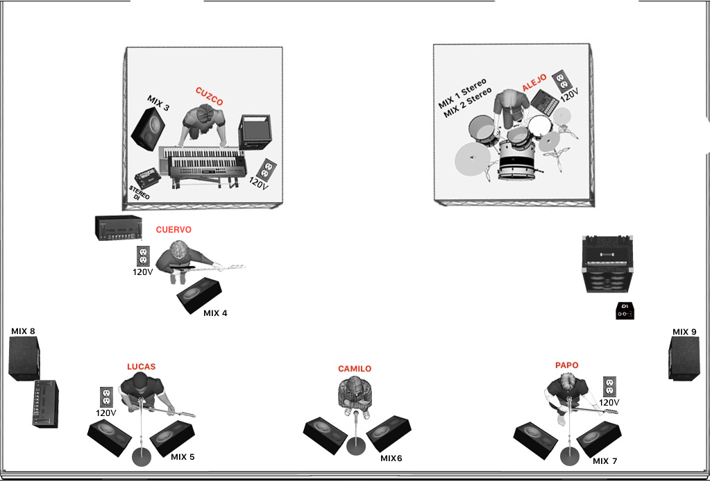

## Input List

| CH | INST | TRANS | BOOM |
| --- | --- | --- | --- |
| 1 | KICK IN | BETA91 | NO |
| 2 | KICK OUT | AUDIX D6 | SHORT |
| 3 | SNARE TOP DYN | SM57 | SHORT |
| 4 | SNARE BOT CON | EARTHWORKS SR25 / KSM37 | NO |
| 5 | HIHAT | EARTHWORKS SR20 / AKG451 | SHORT |
| 6 | T1 | EARTHWORKS DM20 / Senh 904 | CLAW |
| 7 | FLOOR T | EARTHWORKS DM20 / Senh 904 | CLAW |
| 8 | &lt;OH | EARTHWORKS SR25 / KSM37 | LONG |
| 9 | OH&gt; | EARTHWORKS SR25 / KSM37 | LONG |
| 10 | TIMBAL | BETA57 | SHORT |

[output cut: 15 more lines]

## Output monitores

| MIX | MUSICO | MONITOR |
| --- | --- | --- |
| 1 | DRUMS - ALEJO (STEREO) | MIXER STEREO - - 1 - 2 |
| 2 | DRUMS - ALEJO (STEREO) | MIXER STEREO - - 3 - 4 |
| 3 | KEY - CUZCO (MONO) | WEDGE MONO |
| 4 | GTR 2 - CUERVO (MONO) | WEDGE MONO |
| 5 | GTR 1 - LUCAS (MONO) | 2X WEDGE MONO |
| 6 | LEAD VOZ - CAMILO (MONO) | 2X WEDGE MONO |
| 7 | BASS - PAPO (MONO) | 2X WEDGE MONO |
| 8 | SIDE FILL L (MONO) | SIDE FILL L |
| 9 | SIDE FILL R (MONO) | SIDE FILL R |

# Contacto

Produccion: Gonzalo “Chalo” Hernandez chalo.fermin@gmail.com

FOH: Federico Lopez federico1113@gmail.com

Monitores: Giovani Bedoya audiogio@aol.com